# NannanSlides

12/3/2021

## Go-Big-Red

[figure not shown]

## Stadium

[figure not shown]

Memorial Statium

## Nebraska Cornhuskers Team

[figure not shown]

Coach and Players

## American Football Positions

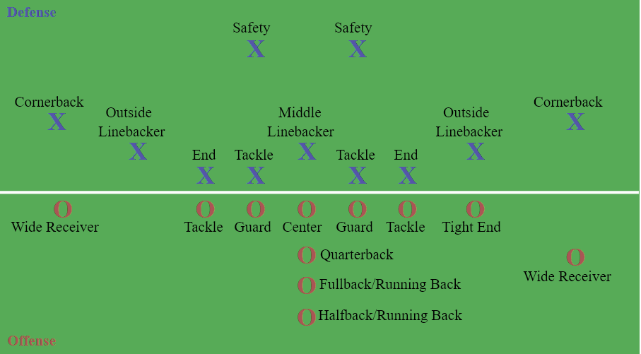

## DataSets

1. Player Salary
2. Coach Salary
3. Coach Record

## Player Salary Variables

**Position**: position played by the player  
**Player**: name  
**Team**: team the player in  
**Age**: age  
**Total_Value**: total amount of money on the contract  
**Ave_Year**: yearly averaged salary  
**Total_guaranteed**: players could get this amount of money after they serve several years for the team  
**Fully_guaranteed**: money guaranteed to get regardless of what happens  
**Free_agency**: time when the contract of the player expires

## Coach Salary Variables

**name**: name of the coach  
**team**: team the coach works for  
**division**: division of the team  
**annual salary**: annual salary  
**net worth**: Total sum of property  
**position**: position of the coach

## Coach Record Variables

**name**: name of the coach  
**Team**: team the coach works for  
**seasons**: seasons the coach coaches  
**Gms**: games Coached  
**W**: games Won  
**L**: games Lost  
**T**: games Tied  
**Yrs**: seasons as head coach  
**post**: number of postseason appearances as head coach  
**pct**: winning Percentage  
**DIV**: division Championships  
**CON**: conference Championships  
**LG**: league Championships  
**SB**: super Bowl Championships

## Average salary of each position

```r
player_salary <- read.csv("player_salary.csv",header = T)
posSa <- player_salary %>% group_by(player_salary$position) %>%
  summarise(avg <- mean(total_value))
posSa <- as.data.frame(posSa)
posSa[order(posSa$`avg <- mean(total_value)`,decreasing=T),]
```

```
##     player_salary$position avg <- mean(total_value)
## 22             quarterback                 19969326
## 4        4-3-defensive-end                 11721723
## 11             edge-rusher                 11647101
## 3   3-4-outside-linebacker                 11195694
## 17             left-tackle                 11013873
## 1        3-4-defensive-end                  9749860
## 10          defensive-line                  9107187
## 20          offensive-line                  9006569
## 24            right-tackle                  8307251
## 7                   center                  8110696
## 23             right-guard                  8096270
## 16              left-guard                  7955430
## 14 interior-defensive-line                  7685334
## 8               cornerback                  7423074
## 5     4-3-defensive-tackle                  7104101
## 18              linebacker                  6874176
## 29           wide-receiver                  6806289
## 9           defensive-back                  6735837
## 6   4-3-outside-linebacker                  6361133
## 28  traditional-linebacker                  5943440
## 26                  safety                  5828116
## 15                  kicker                  5640782
## 13       inside-linebacker                  5628339
## 27               tight-end                  4951559
## 21                  punter                  4773773
## 25            running-back                  4741030
## 2     3-4-defensive-tackle                  3725101
## 12                fullback                  3532030
## 19            long-snapper                  2467010
```

## Number of players of each position

```r
frequency <- player_salary %>% group_by(player_salary$position)%>%
  summarise(n = n())
frequency <- as.data.frame(frequency)
frequency[order(frequency$n,decreasing = T),]
```

```
##     player_salary$position   n
## 9           defensive-back 549
## 20          offensive-line 489
## 10          defensive-line 426
## 29           wide-receiver 383
## 18              linebacker 369
## 8               cornerback 315
## 28  traditional-linebacker 300
## 14 interior-defensive-line 271
## 26                  safety 233
## 11             edge-rusher 218
## 25            running-back 197
## 27               tight-end 195
## 13       inside-linebacker 171
## 4        4-3-defensive-end 153
## 5     4-3-defensive-tackle 142
## 6   4-3-outside-linebacker 129
## 22             quarterback 119
## 17             left-tackle 111
## 23             right-guard 108
## 24            right-tackle 100
## 16              left-guard  97
## 1        3-4-defensive-end  96
## 7                   center  90
## 3   3-4-outside-linebacker  67
## 21                  punter  46
## 15                  kicker  44
## 19            long-snapper  43
## 2     3-4-defensive-tackle  40
## 12                fullback  22
```

## Average salary of each team

```r
teamSa <- player_salary  %>% group_by(player_salary $team) %>%
  summarise(avg <- mean(total_value))
teamSa <- as.data.frame(teamSa)
teamSa[order(teamSa$`avg <- mean(total_value)`,decreasing=T),]
```

```
##    player_salary$team avg <- mean(total_value)
## 32            Vikings                 11155185
## 2               Bears                  9636364
## 1               49ers                  9257978
## 6              Browns                  9013063
## 26           Redskins                  8943277
## 20            Packers                  8803744
## 14             Eagles                  8685926
## 17            Jaguars                  8538031
## 31             Titans                  8362323
## 19              Lions                  8296689
## 12            Cowboys                  8199380
## 24               Rams                  8137855
## 18               Jets                  8026713
## 7          Buccaneers                  8001185
```

[output cut: 18 more lines]

## Average salary of each age group

```r
ageSa <- player_salary  %>% group_by(player_salary $age) %>%
  summarise(avg <- mean(total_value))
ageSa <- as.data.frame(ageSa)
ageSa[order(ageSa$`avg <- mean(total_value)`,decreasing=T),]
```

```
##    player_salary$age avg <- mean(total_value)
## 22                40                 50000000
## 24                42                 41000000
## 20                38                 34395714
## 12                30                 26010008
## 13                31                 24368405
## 16                34                 21186348
## 11                29                 19569907
## 18                36                 16293077
## 10                28                 15938486
## 14                32                 15152429
## 17                35                 14556389
## 19                37                 14531400
## 15                33                 13025213
## 9                 27                  9408572
## 8                 26                  6540394
## 4                 22                  4564270
## 3                 21                  4433961
## 1                  0                  4354536
## 7                 25                  4293364
## 25                47                  3875000
## 5                 23                  3364737
## 6                 24                  3269501
## 21                39                  2350000
## 2                  1                  1770000
## 26               323                  1770000
## 27              2020                  1708512
## 23                41                  1120000
```

## Expolore total value among different age groups

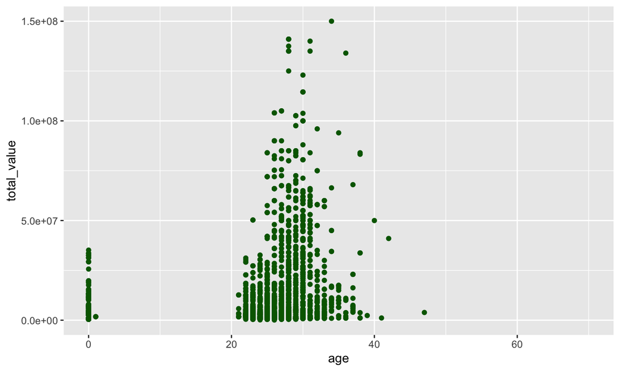

## Is total value positively correlated with fully guaranteed?

```
## [1] 0.9111471
```

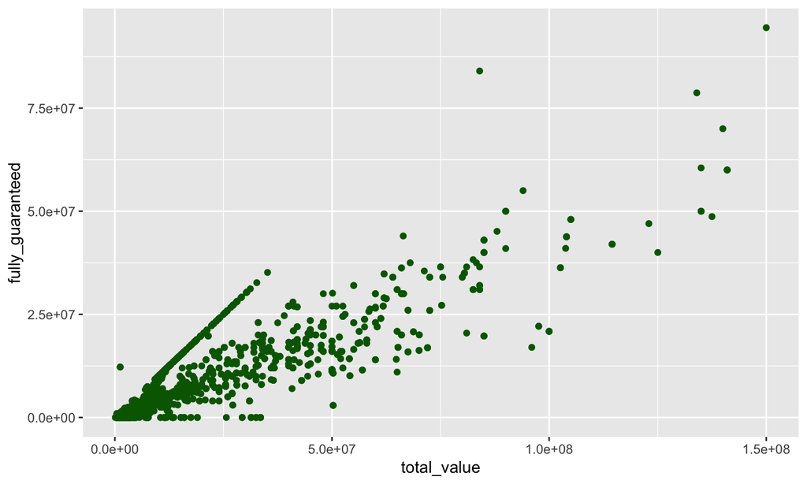